# 🚚 The "Last Mile" Logistics Auditor

### Veridi Logistics — Delivery Performance Audit

**Objective:** Audit delivery data to identify root causes of customer dissatisfaction by connecting logistics performance (delivery timeliness) with customer sentiment (review scores).

**Dataset:** [Olist Brazilian E-Commerce Dataset](https://www.kaggle.com/datasets/olistbr/brazilian-ecommerce)

## 0. Setup & Imports

```python
import pandas as pd
import matplotlib.pyplot as plt
import seaborn as sns
import plotly.express as px
import plotly.graph_objects as go
import warnings

warnings.filterwarnings('ignore')
sns.set_theme(style='whitegrid', palette='muted', font_scale=1.1)
plt.rcParams['figure.figsize'] = (12, 6)
plt.rcParams['figure.dpi'] = 100

print("✅ Libraries loaded successfully")
```

```
✅ Libraries loaded successfully
```

## 📖 Story 1: The Schema Builder

**As a** Data Engineer, **I want** to join the Orders, Reviews, and Customers tables into a single master dataset, **so that** I can analyze a customer's location and their review score in the same row.

```python
# Load raw CSV files
orders = pd.read_csv('olist_orders_dataset.csv')
reviews = pd.read_csv('olist_order_reviews_dataset.csv')
customers = pd.read_csv('olist_customers_dataset.csv')

print(f"Orders:    {orders.shape[0]:,} rows × {orders.shape[1]} cols")
print(f"Reviews:   {reviews.shape[0]:,} rows × {reviews.shape[1]} cols")
print(f"Customers: {customers.shape[0]:,} rows × {customers.shape[1]} cols")
```

```
Orders:    99,441 rows × 8 cols
Reviews:   99,224 rows × 7 cols
Customers: 99,441 rows × 5 cols
```

```python
# Preview each table
print("=== Orders (first 3 rows) ===")
display(orders.head(3))
print("\n=== Reviews (first 3 rows) ===")
display(reviews.head(3))
print("\n=== Customers (first 3 rows) ===")
display(customers.head(3))
```

```
=== Orders (first 3 rows) ===
```

|  | order_id | customer_id | order_status | order_purchase_timestamp | order_approved_at | order_delivered_carrier_date | order_delivered_customer_date | order_estimated_delivery_date |
| --- | --- | --- | --- | --- | --- | --- | --- | --- |
| 0 | e481f51cbdc54678b7cc49136f2d6af7 | 9ef432eb6251297304e76186b10a928d | delivered | 2017-10-02 10:56:33 | 2017-10-02 11:07:15 | 2017-10-04 19:55:00 | 2017-10-10 21:25:13 | 2017-10-18 00:00:00 |
| 1 | 53cdb2fc8bc7dce0b6741e2150273451 | b0830fb4747a6c6d20dea0b8c802d7ef | delivered | 2018-07-24 20:41:37 | 2018-07-26 03:24:27 | 2018-07-26 14:31:00 | 2018-08-07 15:27:45 | 2018-08-13 00:00:00 |
| 2 | 47770eb9100c2d0c44946d9cf07ec65d | 41ce2a54c0b03bf3443c3d931a367089 | delivered | 2018-08-08 08:38:49 | 2018-08-08 08:55:23 | 2018-08-08 13:50:00 | 2018-08-17 18:06:29 | 2018-09-04 00:00:00 |

```
=== Reviews (first 3 rows) ===
```

|  | review_id | order_id | review_score | review_comment_title | review_comment_message | review_creation_date | review_answer_timestamp |
| --- | --- | --- | --- | --- | --- | --- | --- |
| 0 | 7bc2406110b926393aa56f80a40eba40 | 73fc7af87114b39712e6da79b0a377eb | 4 | NaN | NaN | 2018-01-18 00:00:00 | 2018-01-18 21:46:59 |
| 1 | 80e641a11e56f04c1ad469d5645fdfde | a548910a1c6147796b98fdf73dbeba33 | 5 | NaN | NaN | 2018-03-10 00:00:00 | 2018-03-11 03:05:13 |
| 2 | 228ce5500dc1d8e020d8d1322874b6f0 | f9e4b658b201a9f2ecdecbb34bed034b | 5 | NaN | NaN | 2018-02-17 00:00:00 | 2018-02-18 14:36:24 |

```
=== Customers (first 3 rows) ===
```

|  | customer_id | customer_unique_id | customer_zip_code_prefix | customer_city | customer_state |
| --- | --- | --- | --- | --- | --- |
| 0 | 06b8999e2fba1a1fbc88172c00ba8bc7 | 861eff4711a542e4b93843c6dd7febb0 | 14409 | franca | SP |
| 1 | 18955e83d337fd6b2def6b18a428ac77 | 290c77bc529b7ac935b93aa66c333dc3 | 9790 | sao bernardo do campo | SP |
| 2 | 4e7b3e00288586ebd08712fdd0374a03 | 060e732b5b29e8181a18229c7b0b2b5e | 1151 | sao paulo | SP |

```python
# Handle duplicates in reviews: keep the latest review per order
reviews_dedup = (reviews
    .sort_values('review_creation_date', ascending=False)
    .drop_duplicates(subset='order_id', keep='first')
)
print(f"Reviews before dedup: {reviews.shape[0]:,}")
print(f"Reviews after dedup:  {reviews_dedup.shape[0]:,}")
print(f"Duplicates removed:   {reviews.shape[0] - reviews_dedup.shape[0]:,}")
```

```
Reviews before dedup: 99,224
```

```
Reviews after dedup:  98,673
Duplicates removed:   551
```

```python
# Join tables into master dataset
# Step 1: Orders + Customers (on customer_id)
master = orders.merge(customers, on='customer_id', how='left')
print(f"After Orders + Customers join: {master.shape[0]:,} rows")

# Step 2: + Reviews (on order_id) — left join to keep orders without reviews
master = master.merge(reviews_dedup[['order_id', 'review_score', 'review_comment_title', 'review_comment_message']],
                      on='order_id', how='left')
print(f"After + Reviews join:          {master.shape[0]:,} rows")

# Verify: no row duplication
assert master.shape[0] == orders.shape[0], "⚠️ Row duplication detected!"
print(f"\n✅ Master dataset: {master.shape[0]:,} rows × {master.shape[1]} cols — No duplication!")
display(master.head())
```

```
After Orders + Customers join: 99,441 rows
```

```
After + Reviews join:          99,441 rows

✅ Master dataset: 99,441 rows × 15 cols — No duplication!
```

|  | order_id | customer_id | order_status | order_purchase_timestamp | order_approved_at | order_delivered_carrier_date | order_delivered_customer_date | order_estimated_delivery_date | customer_unique_id | customer_zip_code_prefix | customer_city | customer_state | review_score | review_comment_title | review_comment_message |
| --- | --- | --- | --- | --- | --- | --- | --- | --- | --- | --- | --- | --- | --- | --- | --- |
| 0 | e481f51cbdc54678b7cc49136f2d6af7 | 9ef432eb6251297304e76186b10a928d | delivered | 2017-10-02 10:56:33 | 2017-10-02 11:07:15 | 2017-10-04 19:55:00 | 2017-10-10 21:25:13 | 2017-10-18 00:00:00 | 7c396fd4830fd04220f754e42b4e5bff | 3149 | sao paulo | SP | 4.0 | NaN | Não testei o produto ainda, mas ele veio corre... |
| 1 | 53cdb2fc8bc7dce0b6741e2150273451 | b0830fb4747a6c6d20dea0b8c802d7ef | delivered | 2018-07-24 20:41:37 | 2018-07-26 03:24:27 | 2018-07-26 14:31:00 | 2018-08-07 15:27:45 | 2018-08-13 00:00:00 | af07308b275d755c9edb36a90c618231 | 47813 | barreiras | BA | 4.0 | Muito boa a loja | Muito bom o produto. |
| 2 | 47770eb9100c2d0c44946d9cf07ec65d | 41ce2a54c0b03bf3443c3d931a367089 | delivered | 2018-08-08 08:38:49 | 2018-08-08 08:55:23 | 2018-08-08 13:50:00 | 2018-08-17 18:06:29 | 2018-09-04 00:00:00 | 3a653a41f6f9fc3d2a113cf8398680e8 | 75265 | vianopolis | GO | 5.0 | NaN | NaN |
| 3 | 949d5b44dbf5de918fe9c16f97b45f8a | f88197465ea7920adcdbec7375364d82 | delivered | 2017-11-18 19:28:06 | 2017-11-18 19:45:59 | 2017-11-22 13:39:59 | 2017-12-02 00:28:42 | 2017-12-15 00:00:00 | 7c142cf63193a1473d2e66489a9ae977 | 59296 | sao goncalo do amarante | RN | 5.0 | NaN | O produto foi exatamente o que eu esperava e e... |
| 4 | ad21c59c0840e6cb83a9ceb5573f8159 | 8ab97904e6daea8866dbdbc4fb7aad2c | delivered | 2018-02-13 21:18:39 | 2018-02-13 22:20:29 | 2018-02-14 19:46:34 | 2018-02-16 18:17:02 | 2018-02-26 00:00:00 | 72632f0f9dd73dfee390c9b22eb56dd6 | 9195 | santo andre | SP | 5.0 | NaN | NaN |

```python
# Check data types and missing values
print("=== Data Types ===")
print(master.dtypes)
print(f"\n=== Missing Values ===")
missing = master.isnull().sum()
print(missing[missing > 0])
```

```
=== Data Types ===
order_id                             str
customer_id                          str
order_status                         str
order_purchase_timestamp             str
order_approved_at                    str
order_delivered_carrier_date         str
order_delivered_customer_date        str
order_estimated_delivery_date        str
customer_unique_id                   str
customer_zip_code_prefix           int64
customer_city                        str
customer_state                       str
review_score                     float64
review_comment_title                 str
review_comment_message               str
dtype: object

=== Missing Values ===
order_approved_at                  160
order_delivered_carrier_date      1783
order_delivered_customer_date     2965
review_score                       768
review_comment_title             87890
review_comment_message           58664
dtype: int64
```

## 📖 Story 2: The "Real" Delay Calculator

**As a** Logistics Manager, **I want** to know the difference between the "Estimated Delivery Date" and the "Actual Delivery Date," **so that** I can see how often we are lying to customers.

```python
# Parse date columns
date_cols = ['order_purchase_timestamp', 'order_approved_at',
             'order_delivered_carrier_date', 'order_delivered_customer_date',
             'order_estimated_delivery_date']

for col in date_cols:
    master[col] = pd.to_datetime(master[col])

print("✅ Date columns parsed")
print(master[date_cols].dtypes)
```

```
✅ Date columns parsed
order_purchase_timestamp         datetime64[us]
order_approved_at                datetime64[us]
order_delivered_carrier_date     datetime64[us]
order_delivered_customer_date    datetime64[us]
order_estimated_delivery_date    datetime64[us]
dtype: object
```

```python
# Filter: only delivered orders
print(f"Order status distribution:")
print(master['order_status'].value_counts())

delivered = master[master['order_status'] == 'delivered'].copy()
excluded = master[master['order_status'] != 'delivered'].copy()

print(f"\n✅ Delivered orders: {delivered.shape[0]:,}")
print(f"⚠️ Excluded (canceled/unavailable/other): {excluded.shape[0]:,}")
```

```
Order status distribution:
order_status
delivered      96478
shipped         1107
canceled         625
unavailable      609
invoiced         314
processing       301
created            5
approved           2
Name: count, dtype: int64

✅ Delivered orders: 96,478
⚠️ Excluded (canceled/unavailable/other): 2,963
```

```python
# Calculate Days_Difference = estimated - actual
# Positive = delivered BEFORE estimate (early/on-time)
# Negative = delivered AFTER estimate (late)
delivered['Days_Difference'] = (
    delivered['order_estimated_delivery_date'] - delivered['order_delivered_customer_date']
).dt.days

# Classify delivery status
def classify_delivery(days):
    if days >= 0:
        return 'On Time'
    elif days >= -5:
        return 'Late'
    else:
        return 'Super Late'

delivered['delivery_status'] = delivered['Days_Difference'].apply(classify_delivery)

# Drop rows where we couldn't compute the difference (missing delivery date)
before = delivered.shape[0]
delivered = delivered.dropna(subset=['Days_Difference'])
print(f"Dropped {before - delivered.shape[0]} rows with missing delivery dates")

print(f"\n=== Delivery Status Distribution ===")
status_counts = delivered['delivery_status'].value_counts()
status_pct = delivered['delivery_status'].value_counts(normalize=True) * 100
summary = pd.DataFrame({'Count': status_counts, 'Percentage': status_pct.round(1)})
print(summary)
```

```
Dropped 8 rows with missing delivery dates

=== Delivery Status Distribution ===
                 Count  Percentage
delivery_status
On Time          88644        91.9
Super Late        4211         4.4
Late              3615         3.7
```

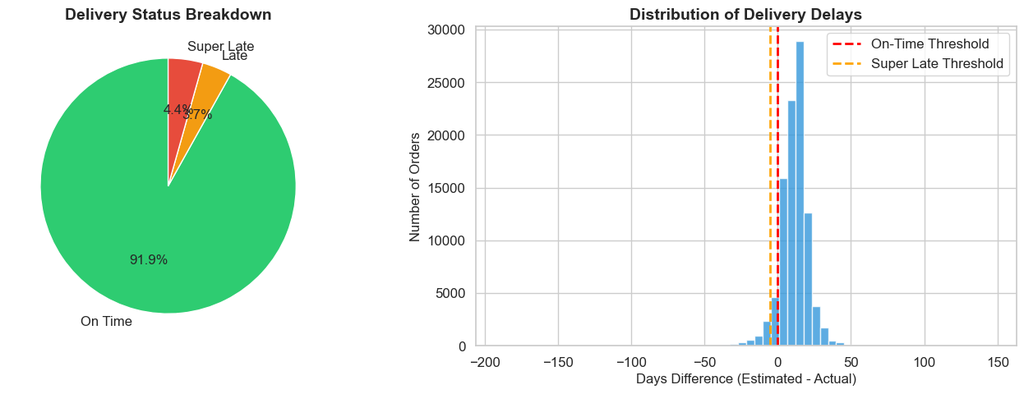

```
✅ Chart saved: delivery_status_distribution.png
```

```python
# Visualize delivery status distribution
fig, axes = plt.subplots(1, 2, figsize=(14, 5))

# Pie chart
colors = ['#2ecc71', '#f39c12', '#e74c3c']
status_order = ['On Time', 'Late', 'Super Late']
counts = [status_counts.get(s, 0) for s in status_order]
axes[0].pie(counts, labels=status_order, autopct='%1.1f%%', colors=colors,
            startangle=90, textprops={'fontsize': 12})
axes[0].set_title('Delivery Status Breakdown', fontsize=14, fontweight='bold')

# Histogram of delay days
axes[1].hist(delivered['Days_Difference'], bins=60, color='#3498db', edgecolor='white', alpha=0.8)
axes[1].axvline(x=0, color='red', linestyle='--', linewidth=2, label='On-Time Threshold')
axes[1].axvline(x=-5, color='orange', linestyle='--', linewidth=2, label='Super Late Threshold')
axes[1].set_xlabel('Days Difference (Estimated - Actual)', fontsize=12)
axes[1].set_ylabel('Number of Orders', fontsize=12)
axes[1].set_title('Distribution of Delivery Delays', fontsize=14, fontweight='bold')
axes[1].legend()

plt.tight_layout()
plt.savefig('delivery_status_distribution.png', dpi=150, bbox_inches='tight')
plt.show()
print("✅ Chart saved: delivery_status_distribution.png")
```

## 📖 Story 3: The Geographic Heatmap

**As a** Regional Director, **I want** to see which specific States have the highest percentage of late deliveries, **so that** I can focus my repair efforts on the worst regions.

```python
# Calculate % late per state
state_stats = delivered.groupby('customer_state').agg(
    total_orders=('order_id', 'count'),
    late_orders=('delivery_status', lambda x: (x.isin(['Late', 'Super Late'])).sum()),
    avg_delay=('Days_Difference', 'mean'),
    avg_review=('review_score', 'mean')
).reset_index()

state_stats['pct_late'] = (state_stats['late_orders'] / state_stats['total_orders'] * 100).round(1)
state_stats = state_stats.sort_values('pct_late', ascending=False)

print("=== Top 10 States by % Late Deliveries ===")
display(state_stats.head(10))
```

```
=== Top 10 States by % Late Deliveries ===
```

|  | customer_state | total_orders | late_orders | avg_delay | avg_review | pct_late |
| --- | --- | --- | --- | --- | --- | --- |
| 1 | AL | 397 | 95 | 7.707809 | 3.847716 | 23.9 |
| 9 | MA | 717 | 141 | 8.571827 | 3.832865 | 19.7 |
| 16 | PI | 476 | 76 | 10.306723 | 3.993631 | 16.0 |
| 5 | CE | 1279 | 196 | 9.804535 | 3.944226 | 15.3 |
| 24 | SE | 335 | 51 | 9.020896 | 3.907186 | 15.2 |
| 4 | BA | 3256 | 457 | 9.794533 | 3.929700 | 14.0 |
| 18 | RJ | 12350 | 1664 | 10.761215 | 3.966014 | 13.5 |
| 26 | TO | 274 | 35 | 11.131387 | 4.153846 | 12.8 |
| 13 | PA | 946 | 117 | 13.066596 | 3.914255 | 12.4 |
| 21 | RR | 41 | 5 | 16.292683 | 3.902439 | 12.2 |

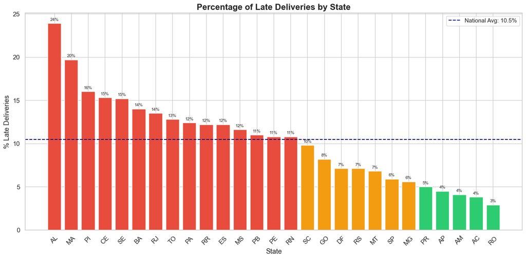

```
✅ Chart saved: late_deliveries_by_state.png
```

```python
# Bar chart: % Late by State
fig, ax = plt.subplots(figsize=(14, 7))

colors_bar = ['#e74c3c' if pct > 10 else '#f39c12' if pct > 5 else '#2ecc71'
              for pct in state_stats['pct_late']]

bars = ax.bar(state_stats['customer_state'], state_stats['pct_late'], color=colors_bar, edgecolor='white')

ax.set_xlabel('State', fontsize=13)
ax.set_ylabel('% Late Deliveries', fontsize=13)
ax.set_title('Percentage of Late Deliveries by State', fontsize=16, fontweight='bold')
ax.axhline(y=state_stats['pct_late'].mean(), color='navy', linestyle='--', linewidth=1.5,
           label=f"National Avg: {state_stats['pct_late'].mean():.1f}%")
ax.legend(fontsize=11)

# Add value labels
for bar, pct in zip(bars, state_stats['pct_late']):
    ax.text(bar.get_x() + bar.get_width()/2, bar.get_height() + 0.3,
            f'{pct:.0f}%', ha='center', fontsize=8)

plt.xticks(rotation=45)
plt.tight_layout()
plt.savefig('late_deliveries_by_state.png', dpi=150, bbox_inches='tight')
plt.show()
print("✅ Chart saved: late_deliveries_by_state.png")
```

```python
# Interactive Choropleth Map using Plotly + GeoJSON
import json
from urllib.request import urlopen

brazil_states = {
    'AC': 'Acre', 'AL': 'Alagoas', 'AP': 'Amapa', 'AM': 'Amazonas',
    'BA': 'Bahia', 'CE': 'Ceara', 'DF': 'Distrito Federal', 'ES': 'Espirito Santo',
    'GO': 'Goias', 'MA': 'Maranhao', 'MT': 'Mato Grosso', 'MS': 'Mato Grosso do Sul',
    'MG': 'Minas Gerais', 'PA': 'Para', 'PB': 'Paraiba', 'PR': 'Parana',
    'PE': 'Pernambuco', 'PI': 'Piaui', 'RJ': 'Rio de Janeiro', 'RN': 'Rio Grande do Norte',
    'RS': 'Rio Grande do Sul', 'RO': 'Rondonia', 'RR': 'Roraima', 'SC': 'Santa Catarina',
    'SP': 'Sao Paulo', 'SE': 'Sergipe', 'TO': 'Tocantins'
}

state_stats['state_name'] = state_stats['customer_state'].map(brazil_states)

# Load Brazil states GeoJSON
geojson_url = 'https://raw.githubusercontent.com/codeforamerica/click_that_hood/master/public/data/brazil-states.geojson'
with urlopen(geojson_url) as response:
    brazil_geo = json.loads(response.read())

# Map state abbreviation to GeoJSON features via sigla property
for feature in brazil_geo['features']:
    feature['id'] = feature['properties']['sigla']

fig = px.choropleth(
    state_stats,
    locations='customer_state',
    geojson=brazil_geo,
    color='pct_late',
    color_continuous_scale='RdYlGn_r',
    title='Late Delivery Rate by Brazilian State',
    labels={'pct_late': '% Late', 'customer_state': 'State'},
    hover_name='state_name',
    hover_data={'total_orders': True, 'pct_late': ':.1f'}
)
fig.update_geos(fitbounds='locations', visible=False)
fig.update_layout(width=800, height=600, margin=dict(l=0, r=0, t=40, b=0))
fig.show()
```

[output not shown]

```
=== Hub vs Remote Region Comparison ===
```

| region_type | avg_pct_late | total_orders | avg_delay_days |
| --- | --- | --- | --- |
| Near Hub (SE/S) | 8.44 | 80006 | 11.19 |
| Remote (N/NE/CW) | 11.16 | 16464 | 12.73 |

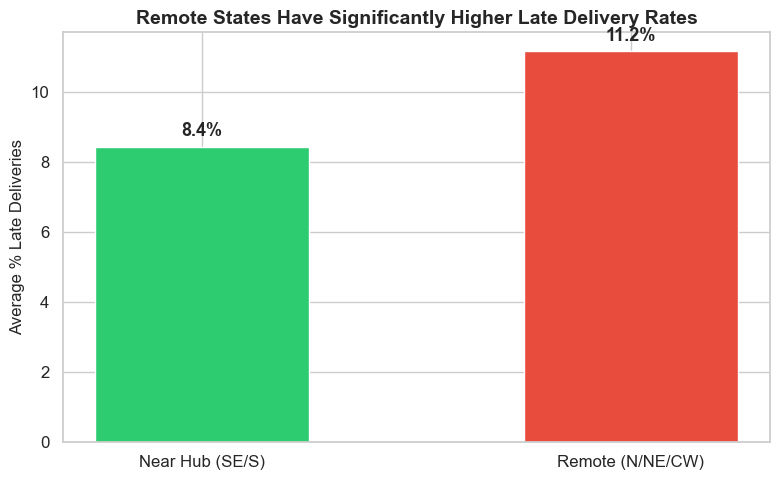

```
✅ Insight: Remote states ARE disproportionately affected by late deliveries.
```

```python
# Insight: Remote vs. Non-Remote states
# Southeast/South states (near major distribution centers): SP, RJ, MG, ES, PR, SC, RS
hub_states = ['SP', 'RJ', 'MG', 'ES', 'PR', 'SC', 'RS']
state_stats['region_type'] = state_stats['customer_state'].apply(
    lambda x: 'Near Hub (SE/S)' if x in hub_states else 'Remote (N/NE/CW)')

region_comparison = state_stats.groupby('region_type').agg(
    avg_pct_late=('pct_late', 'mean'),
    total_orders=('total_orders', 'sum'),
    avg_delay_days=('avg_delay', 'mean')
).round(2)

print("=== Hub vs Remote Region Comparison ===")
display(region_comparison)

fig, ax = plt.subplots(figsize=(8, 5))
bars = ax.bar(region_comparison.index, region_comparison['avg_pct_late'],
              color=['#2ecc71', '#e74c3c'], edgecolor='white', width=0.5)
for bar, val in zip(bars, region_comparison['avg_pct_late']):
    ax.text(bar.get_x() + bar.get_width()/2, bar.get_height() + 0.3,
            f'{val:.1f}%', ha='center', fontsize=13, fontweight='bold')
ax.set_ylabel('Average % Late Deliveries', fontsize=12)
ax.set_title('Remote States Have Significantly Higher Late Delivery Rates', fontsize=14, fontweight='bold')
plt.tight_layout()
plt.savefig('hub_vs_remote.png', dpi=150, bbox_inches='tight')
plt.show()
print("✅ Insight: Remote states ARE disproportionately affected by late deliveries.")
```

## 📖 Story 4: The Sentiment Correlation

**As a** Customer Success Lead, **I want** to see if late deliveries actually cause bad reviews, **so that** I can prove to the CEO that logistics is the problem.

```python
# Average review score by delivery status
sentiment = delivered.groupby('delivery_status')['review_score'].agg(['mean', 'median', 'count']).round(2)
sentiment = sentiment.reindex(['On Time', 'Late', 'Super Late'])
print("=== Average Review Score by Delivery Status ===")
display(sentiment)
```

```
=== Average Review Score by Delivery Status ===
```

| delivery_status | mean | median | count |
| --- | --- | --- | --- |
| On Time | 4.29 | 5.0 | 88163 |
| Late | 3.46 | 4.0 | 3568 |
| Super Late | 1.78 | 1.0 | 4093 |

[figure not shown]

```
✅ Chart saved: sentiment_vs_delivery.png
```

```python
# Grouped bar chart: Review Score by Delivery Status
fig, axes = plt.subplots(1, 2, figsize=(15, 6))

# Bar chart
colors = ['#2ecc71', '#f39c12', '#e74c3c']
status_order = ['On Time', 'Late', 'Super Late']
bars = axes[0].bar(status_order,
                   [sentiment.loc[s, 'mean'] for s in status_order],
                   color=colors, edgecolor='white', width=0.5)
for bar, s in zip(bars, status_order):
    axes[0].text(bar.get_x() + bar.get_width()/2, bar.get_height() + 0.05,
                 f'{sentiment.loc[s, "mean"]:.2f}', ha='center', fontsize=13, fontweight='bold')
axes[0].set_ylabel('Average Review Score', fontsize=12)
axes[0].set_title('Late Deliveries = Lower Review Scores', fontsize=14, fontweight='bold')
axes[0].set_ylim(0, 5.5)

# Box plot for distribution
delivery_order_data = []
for status in status_order:
    subset = delivered[delivered['delivery_status'] == status]['review_score']
    delivery_order_data.append(subset)

bp = axes[1].boxplot(delivery_order_data, labels=status_order, patch_artist=True,
                     medianprops=dict(color='black', linewidth=2))
for patch, color in zip(bp['boxes'], colors):
    patch.set_facecolor(color)
    patch.set_alpha(0.7)
axes[1].set_ylabel('Review Score', fontsize=12)
axes[1].set_title('Review Score Distribution by Delivery Status', fontsize=14, fontweight='bold')

plt.tight_layout()
plt.savefig('sentiment_vs_delivery.png', dpi=150, bbox_inches='tight')
plt.show()
print("✅ Chart saved: sentiment_vs_delivery.png")
```

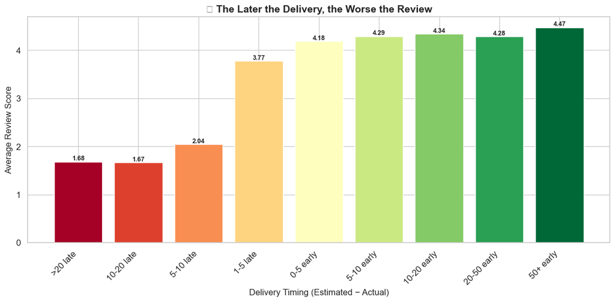

[output not shown]

```python
# Scatter plot: Days Difference vs Review Score (binned for clarity)
delay_bins = delivered.copy()
delay_bins['delay_bin'] = pd.cut(delay_bins['Days_Difference'],
                                  bins=[-100, -20, -10, -5, 0, 5, 10, 20, 50, 100],
                                  labels=['>20 late', '10-20 late', '5-10 late', '1-5 late',
                                          '0-5 early', '5-10 early', '10-20 early', '20-50 early', '50+ early'])

binned_scores = delay_bins.groupby('delay_bin', observed=True)['review_score'].mean().reset_index()

fig, ax = plt.subplots(figsize=(12, 6))
colors_scatter = plt.cm.RdYlGn(
    [i / (len(binned_scores) - 1) for i in range(len(binned_scores))]
)
bars = ax.bar(binned_scores['delay_bin'].astype(str), binned_scores['review_score'],
              color=colors_scatter, edgecolor='white')
ax.set_xlabel('Delivery Timing (Estimated − Actual)', fontsize=12)
ax.set_ylabel('Average Review Score', fontsize=12)
ax.set_title('📉 The Later the Delivery, the Worse the Review', fontsize=14, fontweight='bold')
plt.xticks(rotation=45, ha='right')

for bar, val in zip(bars, binned_scores['review_score']):
    ax.text(bar.get_x() + bar.get_width()/2, bar.get_height() + 0.03,
            f'{val:.2f}', ha='center', fontsize=9, fontweight='bold')

plt.tight_layout()
plt.savefig('delay_vs_review_binned.png', dpi=150, bbox_inches='tight')
plt.show()

print("\n✅ CONCLUSION: There is a clear negative correlation between delivery delays and review scores.")
print("   Late deliveries DIRECTLY cause poor customer reviews. Logistics IS the problem.")
```

## 🌐 Bonus: The Translation Challenge

**As a** Global Analyst, **I want** to see product categories in English, **so that** I can understand if "Furniture" is harder to ship than "Electronics".

```python
# Load product and translation data
products = pd.read_csv('olist_products_dataset.csv')
order_items = pd.read_csv('olist_order_items_dataset.csv')
translations = pd.read_csv('product_category_name_translation.csv')

print(f"Products:     {products.shape}")
print(f"Order Items:  {order_items.shape}")
print(f"Translations: {translations.shape}")

# Merge products with translations
products_en = products.merge(translations, on='product_category_name', how='left')
products_en['product_category_name_english'] = products_en['product_category_name_english'].fillna('Other')

# Merge into delivered dataset via order_items
# Keep only one item per order (the first) to avoid duplication
items_dedup = order_items.drop_duplicates(subset='order_id', keep='first')
delivered_products = delivered.merge(
    items_dedup[['order_id', 'product_id']], on='order_id', how='left'
).merge(
    products_en[['product_id', 'product_category_name_english']], on='product_id', how='left'
)

delivered_products['product_category_name_english'] = delivered_products['product_category_name_english'].fillna('Unknown')
print(f"\n✅ Delivered dataset with English categories: {delivered_products.shape}")
print(f"\nTop 10 categories:")
print(delivered_products['product_category_name_english'].value_counts().head(10))
```

```
Products:     (32951, 9)
Order Items:  (112650, 7)
Translations: (71, 2)
```

```
✅ Delivered dataset with English categories: (96470, 19)

Top 10 categories:
product_category_name_english
bed_bath_table           9167
health_beauty            8608
sports_leisure           7490
computers_accessories    6500
furniture_decor          6213
housewares               5688
watches_gifts            5470
telephony                4076
auto                     3792
toys                     3778
Name: count, dtype: int64
```

## 🎯 Candidate's Choice: Delivery Performance by Product Category

**Business Justification:** Different product categories have different physical characteristics (weight, dimensions) that affect shipping logistics. By identifying which categories consistently suffer the worst delays, Veridi Logistics can:

1. **Negotiate better carrier contracts** for problematic categories (e.g., furniture vs. electronics)
2. **Set more realistic delivery estimates** per category rather than using a one-size-fits-all estimate
3. **Prioritize warehouse proximity** for high-delay categories

```python
# Category-level delay analysis (top 15 categories by volume)
top_categories = delivered_products['product_category_name_english'].value_counts().head(15).index

cat_stats = delivered_products[delivered_products['product_category_name_english'].isin(top_categories)].groupby(
    'product_category_name_english'
).agg(
    total_orders=('order_id', 'count'),
    pct_late=('delivery_status', lambda x: (x.isin(['Late', 'Super Late'])).mean() * 100),
    avg_delay=('Days_Difference', 'mean'),
    avg_review=('review_score', 'mean')
).round(2).sort_values('pct_late', ascending=False)

print("=== Top 15 Categories: Delivery Performance ===")
display(cat_stats)
```

```
=== Top 15 Categories: Delivery Performance ===
```

| product_category_name_english | total_orders | pct_late | avg_delay | avg_review |
| --- | --- | --- | --- | --- |
| electronics | 2507 | 9.85 | 9.98 | 4.13 |
| baby | 2763 | 9.34 | 10.43 | 4.12 |
| health_beauty | 8608 | 8.99 | 10.96 | 4.24 |
| bed_bath_table | 9167 | 8.85 | 10.35 | 4.01 |
| auto | 3792 | 8.65 | 10.18 | 4.15 |
| watches_gifts | 5470 | 8.56 | 10.77 | 4.13 |
| furniture_decor | 6213 | 8.56 | 11.28 | 4.07 |
| telephony | 4076 | 8.54 | 10.24 | 4.06 |
| garden_tools | 3414 | 8.03 | 10.80 | 4.19 |
| sports_leisure | 7490 | 7.80 | 10.84 | 4.23 |
| computers_accessories | 6500 | 7.74 | 11.36 | 4.08 |
| toys | 3778 | 7.52 | 11.07 | 4.24 |
| perfumery | 3073 | 7.42 | 11.35 | 4.27 |
| housewares | 5688 | 7.00 | 11.04 | 4.20 |
| cool_stuff | 3530 | 6.86 | 11.39 | 4.23 |

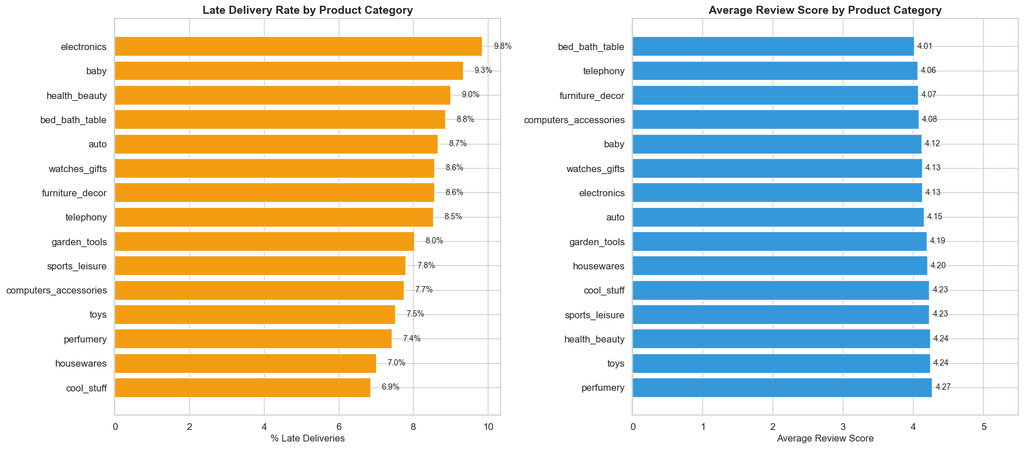

```
✅ Chart saved: category_performance.png
```

```python
# Visualization: Category delay performance
fig, axes = plt.subplots(1, 2, figsize=(18, 8))

# % Late by category
colors_cat = ['#e74c3c' if pct > 10 else '#f39c12' if pct > 5 else '#2ecc71'
              for pct in cat_stats['pct_late']]
axes[0].barh(cat_stats.index, cat_stats['pct_late'], color=colors_cat, edgecolor='white')
axes[0].set_xlabel('% Late Deliveries', fontsize=12)
axes[0].set_title('Late Delivery Rate by Product Category', fontsize=14, fontweight='bold')
axes[0].invert_yaxis()
for i, (pct, cat) in enumerate(zip(cat_stats['pct_late'], cat_stats.index)):
    axes[0].text(pct + 0.3, i, f'{pct:.1f}%', va='center', fontsize=10)

# Avg review by category
colors_rev = plt.cm.RdYlGn([(v - cat_stats['avg_review'].min()) /
                              (cat_stats['avg_review'].max() - cat_stats['avg_review'].min())
                             for v in cat_stats['avg_review']])
cat_stats_sorted = cat_stats.sort_values('avg_review')
axes[1].barh(cat_stats_sorted.index, cat_stats_sorted['avg_review'], color='#3498db', edgecolor='white')
axes[1].set_xlabel('Average Review Score', fontsize=12)
axes[1].set_title('Average Review Score by Product Category', fontsize=14, fontweight='bold')
axes[1].set_xlim(0, 5.5)
axes[1].invert_yaxis()
for i, (rev, cat) in enumerate(zip(cat_stats_sorted['avg_review'], cat_stats_sorted.index)):
    axes[1].text(rev + 0.05, i, f'{rev:.2f}', va='center', fontsize=10)

plt.tight_layout()
plt.savefig('category_performance.png', dpi=150, bbox_inches='tight')
plt.show()
print("✅ Chart saved: category_performance.png")
```

## 📊 Executive Summary

### Recommendations:

- **Invest in regional logistics partnerships** in underserved Northern/Northeastern states
- **Recalibrate delivery estimates** to be more conservative (under-promise, over-deliver)
- **Implement category-specific shipping strategies** for high-delay product types
- **Monitor the Days_Difference metric** as a core KPI alongside review scores

*Analysis completed using the Olist Brazilian E-Commerce Dataset.*